# Part II - Explanatory of Ford GoBike System Data

## Investigation Overview

We got data for bike sharing system in San Francisco Bay area. Let's do some analysis to understand who are using our bikes, for how long and do we need to provide more bike for special time period?

- Who are using our bikes - what is the age range?
- Most bike usage in terms of time and day.
- Do we need to provide more bikes?

## Dataset Overview and Executive Summary

Data set includes information about individual rides made in a bike-sharing system covering the greater San Francisco Bay area.

```python
# import all packages and set plots to be embedded inline
import numpy as np
import pandas as pd
import matplotlib.pyplot as plt
import seaborn as sns

# suppress warnings from final output
import warnings
warnings.simplefilter("ignore")
```

```python
# load in the dataset into a pandas dataframe

df = pd.read_csv('201902-fordgobike-tripdata_cleaned.csv')
df.info()
```

```
<class 'pandas.core.frame.DataFrame'>
RangeIndex: 174689 entries, 0 to 174688
Data columns (total 13 columns):
 #   Column                   Non-Null Count   Dtype
---  ------                   --------------   -----
 0   duration_sec             174689 non-null  int64
 1   start_time               174689 non-null  object
 2   end_time                 174689 non-null  object
 3   start_station_name       174689 non-null  object
 4   end_station_name         174689 non-null  object
 5   bike_id                  174689 non-null  int64
 6   user_type                174689 non-null  object
 7   member_birth_year        174689 non-null  int64
 8   member_gender            174689 non-null  object
 9   bike_share_for_all_trip  174689 non-null  object
 10  member_age               174689 non-null  int64
 11  start_weekday            174689 non-null  object
 12  start_hour               174689 non-null  int64
dtypes: int64(5), object(8)
memory usage: 17.3+ MB
```

```python
# correcting the column types
dtype= {'start_time': 'datetime64[ns]',
        'end_time': 'datetime64[ns]',

        'user_type': 'category',
        'member_gender': 'category',
        'bike_share_for_all_trip': 'category'}
df = df.astype(dtype)

# prepare day_order sequence for the plot
day_order = ['Monday', 'Tuesday', 'Wednesday', 'Thursday', 'Friday', 'Saturday', 'Sunday']
df.info()
```

```
<class 'pandas.core.frame.DataFrame'>
RangeIndex: 174689 entries, 0 to 174688
Data columns (total 13 columns):
 #   Column                   Non-Null Count   Dtype
---  ------                   --------------   -----
 0   duration_sec             174689 non-null  int64
 1   start_time               174689 non-null  datetime64[ns]
 2   end_time                 174689 non-null  datetime64[ns]
 3   start_station_name       174689 non-null  object
 4   end_station_name         174689 non-null  object
 5   bike_id                  174689 non-null  int64
 6   user_type                174689 non-null  category
 7   member_birth_year        174689 non-null  int64
 8   member_gender            174689 non-null  category
 9   bike_share_for_all_trip  174689 non-null  category
 10  member_age               174689 non-null  int64
 11  start_weekday            174689 non-null  object
 12  start_hour               174689 non-null  int64
dtypes: category(3), datetime64[ns](2), int64(5), object(3)
memory usage: 13.8+ MB
```

## Who are using our bikes - what is the age range?

What is the age range for bike sharing?

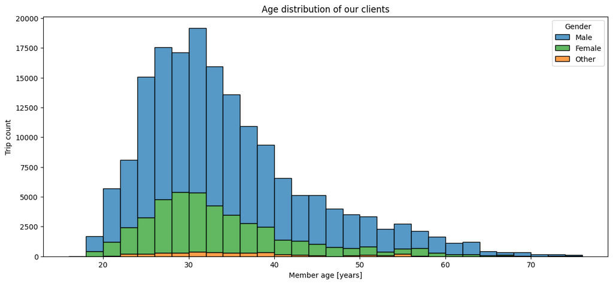

```python
# plot the dustribution of members by age
# get the bins based on min and max value of member_age
gender_order = ['Male', 'Female', 'Other']
plt.figure(figsize=[14, 6])
bins=np.arange(min(df['member_age'])-2, max(df['member_age'])+2, 2);
ax = sns.histplot(data = df,
                 x = 'member_age',
                 hue='member_gender',
                 hue_order=gender_order,
                 palette=['tab:blue', 'tab:green', 'tab:orange'],
                 bins=bins,
                 multiple='stack')

# correct legend title
ax.get_legend().set_title('Gender')

# Format the plot's visual
plt.title('Age distribution of our clients');
plt.xlabel('Member age [years]');
plt.ylabel('Trip count');
```

**Finding 1** As we expected, members aged between 25 and 40 emerge as the primary users of the bike-sharing program, suggesting a strong engagement within this demographic. We can say that the presence of users across a wide age range highlights the inclusivity and accessibility of the bike-sharing program, catering to both younger and older demographics.

As a owner of bike sharing company, I want to know, when bikes are mostly used: during the day, during the weekday.

## When our bikes are used - in terms of time and day

Let's investigate, when bikes are famous, and on when clients are using it more

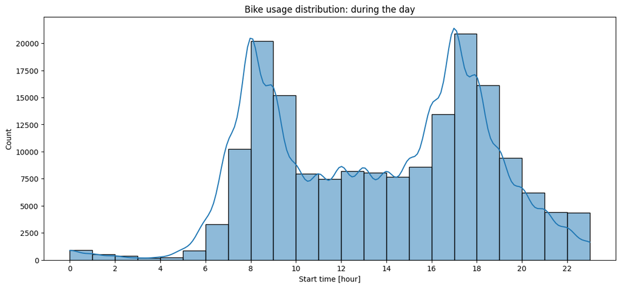

```python
# get when (in terms of time of the day) bikes are popular
plt.figure(figsize=[14, 6])
sns.histplot(data=df, x='start_hour', binwidth=1, kde=True);
plt.xlabel('Start time [hour]')
plt.ylabel('Count')
plt.title('Bike usage distribution: during the day')
plt.xticks([t for t in range(24) if t%2==0]);
```

**Finding:** The distribution of bike usage throughout the day is bimodal, indicating the presence of two distinct peaks. The first peak occurs at 8 am, suggesting a significant surge in bike usage during the early morning hours, possibly coinciding with the start of the workday. The second peak is observed at 5 pm, signifying another notable increase in bike usage in the late afternoon, which could correspond to the end of the workday.

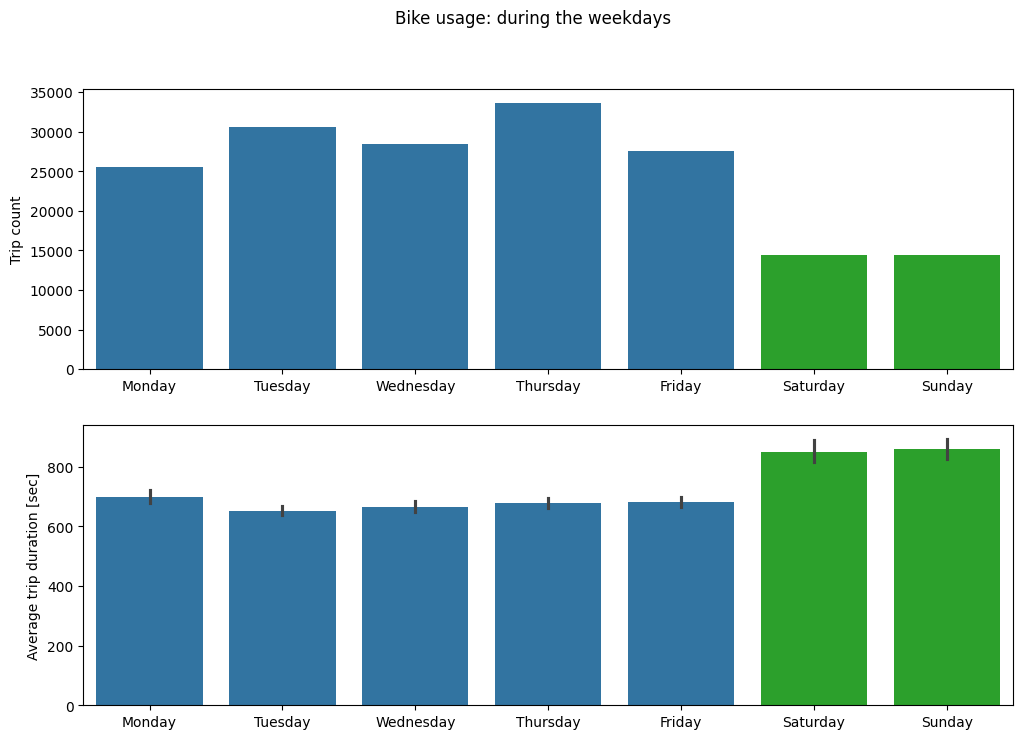

```python
fig, axes = plt.subplots(2)
fig.set_size_inches(12, 8)
fig.suptitle('Bike usage: during the weekdays')
ax1 = sns.countplot(ax=axes[0], data=df, x='start_weekday', order=day_order);
ax2 = sns.barplot(ax=axes[1], data=df, x='start_weekday', y='duration_sec', order=day_order);

axes[0].set(ylabel='Trip count', xlabel='',)
axes[1].set(ylabel='Average trip duration [sec]', xlabel='')

for i in range(5, 7):
    ax1.patches[i].set_facecolor('tab:green')
    ax2.patches[i].set_facecolor('tab:green')
```

**Finding:**

*Weekday vs. Weekend Trip Count:* The analysis reveals a noticeable decrease in the overall trip count during weekends compared to weekdays. This suggests that there is a discernible difference in bike usage patterns between weekdays and weekends.

*Average Trip Duration:* Interestingly, despite the lower trip count on weekends, the average trip duration shows an increase during this period. This indicates that while fewer trips are taken on weekends, the individual bike rides tend to be longer in duration.

We should consider the possibility that, weekdays may be characterized by more utilitarian bike usage, such as commuting to work or running errands, whereas weekends may see a greater emphasis on leisure and recreational activities.

### Submission

If you are using classroom workspace, you can choose from the following two ways of submission:

1. **Submit from the workspace**. Make sure you have removed the example project from the /home/workspace directory. You must submit the following files:
   - Part_I_notebook.ipynb
   - Part_I_notebook.html or pdf
   - Part_II_notebook.ipynb
   - Part_II_notebook.html or pdf
2. **Submit a zip file on the last page of this project lesson**. In this case, open the Jupyter terminal and run the command below to generate a ZIP file.

```
zip -r my_project.zip .
```

The command abobve will ZIP every file present in your /home/workspace directory. Next, you can download the zip to your local, and follow the instructions on the last page of this project lesson.